# Submitted data error checks

# 0. Instructions for submitters

Submitters should use this file to check for problems with submitted data. Send either a list of problems or confirmation that everything looks OK to Sasha by email. Be sure to reference the dataset version and file creation date/time when doing so. These are:

```
## Version:  2.51
```

```
## [1] "Date/time: 2024-07-15 14:57:30.587256"
```

Each of these html files contains a summary of the data from a single submitted spreadsheet file. The html name is based on the name of the submitted file. Use the details below to check:

- Institute abbreviation, submitter and contributor names
- The plot location(s), using the map zoom and pan features if needed
- For problems in the first sections; “OK” means there are no problems in a particular section, “warning” is something that should be checked (but might be OK), “error” is a problem that needs to be addressed
- For numeric values outside the expected range in the “Value checks” section
- Variables with missing values–are there any missing that you thought you included?
- Plots of flux, cumulative emission over time, and final cumulative emission for strange patterns, unexpectedly high or low values
- Plots of weather data for appropriate differences between plots and expected diurnal or other patterns
- Plots of manure and application data for correct values

Finally, the numeric summary at the end might provide details that can help in pinpointing problems, but typically does not need to be checked.

# 1. Submitter

| inst.abbrev | submitter | version | date |
| --- | --- | --- | --- |
| TI | Buchen-Tschiskale, Caroline | 1 | 2024-04-15 |

# 2. Contributors

| contributor | institute |
| --- | --- |
| ten Huf, Martin | Faculty of Agricultural Sciences and Landscape Architecture, University of Applied Sciences Osnabrück |
| Olfs, Hans-Werner | Faculty of Agricultural Sciences and Landscape Architecture, University of Applied Sciences Osnabrück |
| Nyameasem, John Kormla | Institute of Crop Science and Plant Breeding, Grass and Forage Science/Organic Agriculture, Christian-Albrechts-University Kiel |
| Reinsch, Thorsten | Institute of Crop Science and Plant Breeding, Grass and Forage Science/Organic Agriculture, Christian-Albrechts-University Kiel |
| Kluß, Christof | Institute of Crop Science and Plant Breeding, Grass and Forage Science/Organic Agriculture, Christian-Albrechts-University Kiel |
| Zutz, Mareike | Institute of Crop Science and Plant Breeding, Grass and Forage Science/Organic Agriculture, Christian-Albrechts-University Kiel |
| Essich, Christoph | Institute of Crop Science, Department “Fertilization and Soil Matter Dynamics”, University of Hohenheim |
| Ruser, Reiner | Institute of Crop Science, Department “Fertilization and Soil Matter Dynamics”, University of Hohenheim |
| Flessa, Heinz | Thünen Institute of Climate-Smart Agriculture, Federal Research Institute for Rural Areas, Forestry and Fisheries |

# 3. File and directory names

```
## [1] "../../data-submitted/03/TI"
```

```
## [1] "../../data-submitted/03/TI/ALFAM2_template_7.0_GülleBest_BW_HOH_20240415.xlsx"
```

# 4. Location

[interactive chart not shown]

# 5.Keys and codes

## Codes in Treatments sheet

```
## OK
```

```
## OK
```

## Codes in Plots sheet

```
## OK
```

```
## OK
```

## Codes in Emission sheet

```
## OK
```

```
## OK
```

## Code merge check (matching project, experiment, field, plot, treatment)

```
## OK
```

```
## OK
```

```
## OK
```

```
## OK
```

```
## OK
```

# 6. Publication info

## Check for missing codes

```
## OK
```

```
## OK
```

## Complete citations given

```
## OK
```

```
## OK
```

# 7. Emission sheet

## Duplicated intervals

```
## OK
```

## Missing incorporation time

```
## OK
```

## Delay after application

```
## OK
```

## Missing or double interval number

[output not shown]

[output cut: 169 more lines]

[output not shown]

## Missing time between intervals

```
## [1] "Problem, see following rows (compare start time to end time in previous rows):"
##  [1] 1417 1418 1419 1420 1421 1422 1423 1424 1425 1426 1427 1428 1429 1430 1431
## [16] 1432 1433 1435 1436 1437 1438 1439 1440
## [1] "Problem, see following rows (compare start time to end time in previous rows):"
##  [1] 1536 1537 1538 1539 1540 1541 1542 1543 1544 1545 1546 1547 1548 1549 1550
## [16] 1551 1552 1553 1554 1555 1556 1557 1558 1559
## [1] "Problem, see following rows (compare start time to end time in previous rows):"
##  [1] 1656 1657 1658 1659 1660 1661 1662 1663 1664 1665 1666 1667 1668 1669 1670
## [16] 1671 1672 1673 1674 1675 1676 1677 1678 1679
## [1] "Problem, see following rows (compare start time to end time in previous rows):"
##  [1] 1775 1776 1777 1778 1779 1780 1781 1782 1783 1784 1785 1786 1787 1788 1789
## [16] 1790 1791 1792 1793 1794 1795 1796 1797 1798
## [1] "Problem, see following rows (compare start time to end time in previous rows):"
##  [1] 1488 1489 1490 1491 1492 1493 1494 1495 1496 1497 1498 1499 1500 1501 1502
## [16] 1503 1504 1505 1506 1507 1508 1509 1510
```

[output cut: 529 more lines]

## Measurement method and units

Measurement technique:

| Method | Frequency |
| --- | --- |
| CPS | 4299 |

Measurement technique classification:

| Classification | Frequency |
| --- | --- |
| chamber | 4299 |

Emission units and conversion factors.

| Original unit | Conversion factor applied | Final unit |
| --- | --- | --- |
| kg N/ha-hr | 1 | kg N/ha-hr |

# 7. Value checks

Check to see if submitted values are within a reasonable range.

## Weather

```
## wind : OK
## rain.rate : OK
## air.temp : OK
## soil.temp : OK
## soil.temp.surf : No values to check.
## air.temp.z : OK
## wind.z : OK
```

## Manure and application

```
## man.stor : No values to check.
## man.dm : OK
## man.vs : No values to check.
## man.tkn : OK
## man.tan : OK
## man.tic : No values to check.
## man.ua : No values to check.
## man.vfa : No values to check.
## man.ph : OK
## app.rate : OK
## crop.z : No values to check.
```

## Emission

```
## j.NH3 : OK
## e.int : OK
## e.rel : Some values out of range
## [1] 0.000456887 1.636176194
```

# 8. Missing values

Check for missing values.

## All variables

```
## Some values missing:
## Table below has number of missing observations by variable:
##     soil.water   soil.water.v     soil.moist man.source.det        man.bed
##           4299           4299           4299           4299           4299
##        man.con       man.trt2       man.trt3       man.stor         man.dm
##           4299           4299           4299           4299            652
##         man.vs        man.tkn        man.tan        man.tic         man.ua
##           4299            652            652           4299           4299
##        man.vfa         man.ph        app.end       app.rate         incorp
##           4299            652           4299           1746           4299
##    time.incorp       man.area       dist.inj       furrow.z       furrow.w
##           4299           4299           3162           3162           4299
##           crop         crop.z      crop.area            lai     notes.plot
##             25           4299           4299           4299           3649
##   app.end.orig        tan.app          bg.dl         bg.val        bg.unit
##           4299           1746           4299           4299           4299
##        pH.surf soil.temp.surf            rad            MOL          ustar
##           4299           4299           4299           4299           4299
##             rl       air.pres             rh        far.loc          e.rel
##           4299           4299           4299           4299           1746
##          j.rel     soil.type2         exper2           rep2      crop.orig
##           1746           4299           4299           4299             25
##    incorp.orig
##           4299
```

## Application method and measurement method

```
## OK
```

```
## OK
```

# 9. Plots

## Calculated cumulative emission

Cumulative emission. Missing values imputed (linear interpolation). Numeric labels show position of data in data file: row in the “Plots” sheet and first row in the “Emission” sheet. Labels in center of the first plot have measurement method, manure source, and application method. The same emission data are plotted a few different ways to facilitate checking for problems, e.g., comparing plot to each other or checking application dates. The same colors should be be used for particular field plots throughout this section.

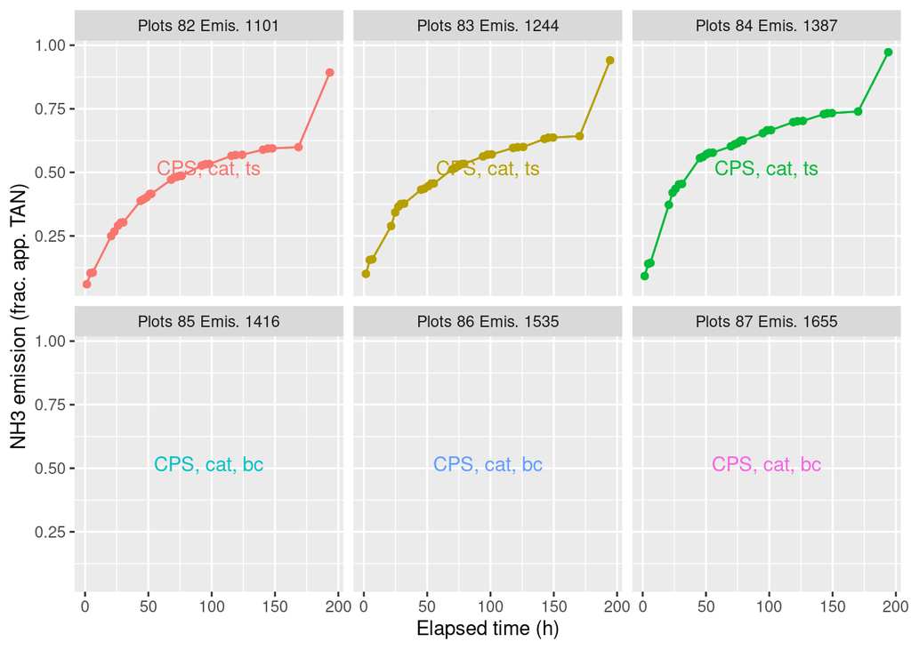

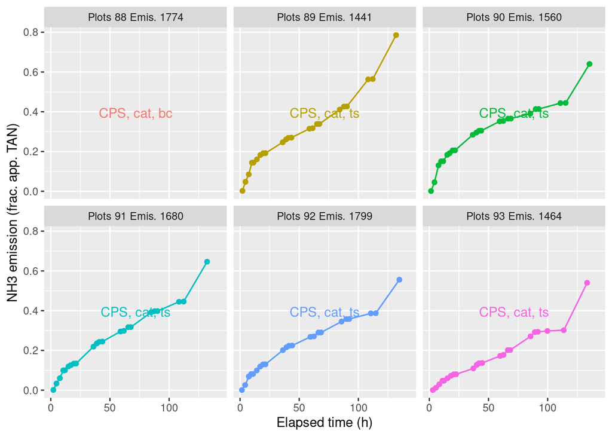

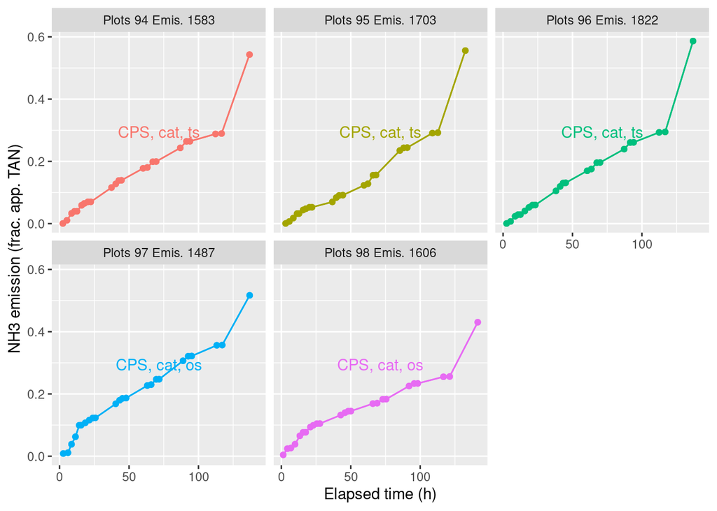

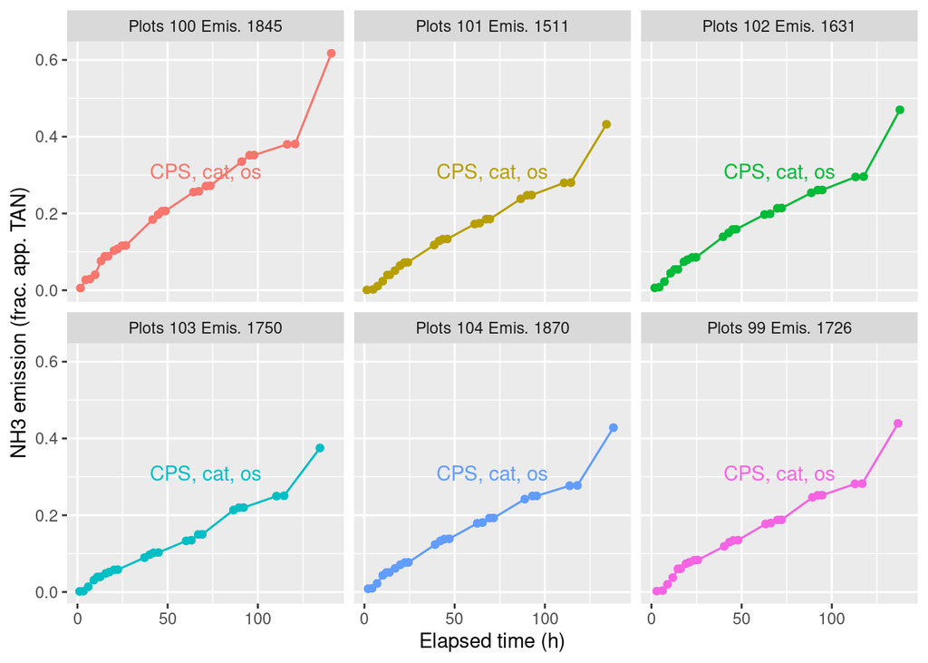

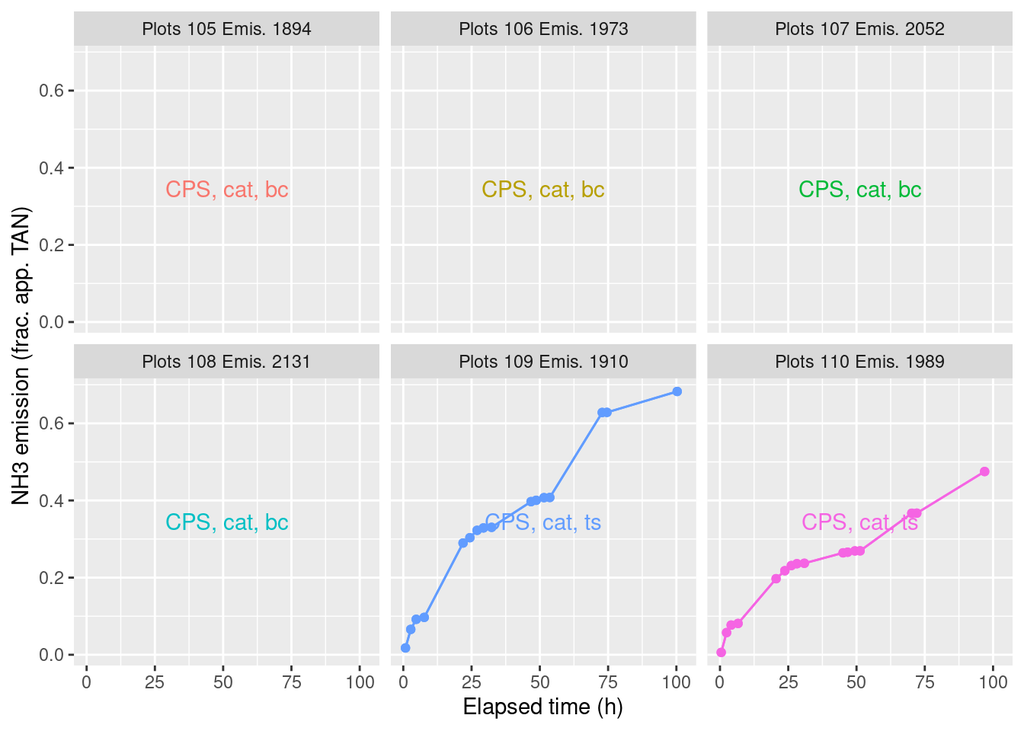

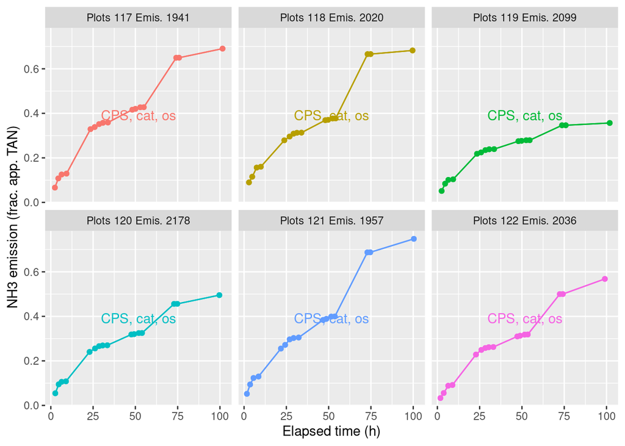

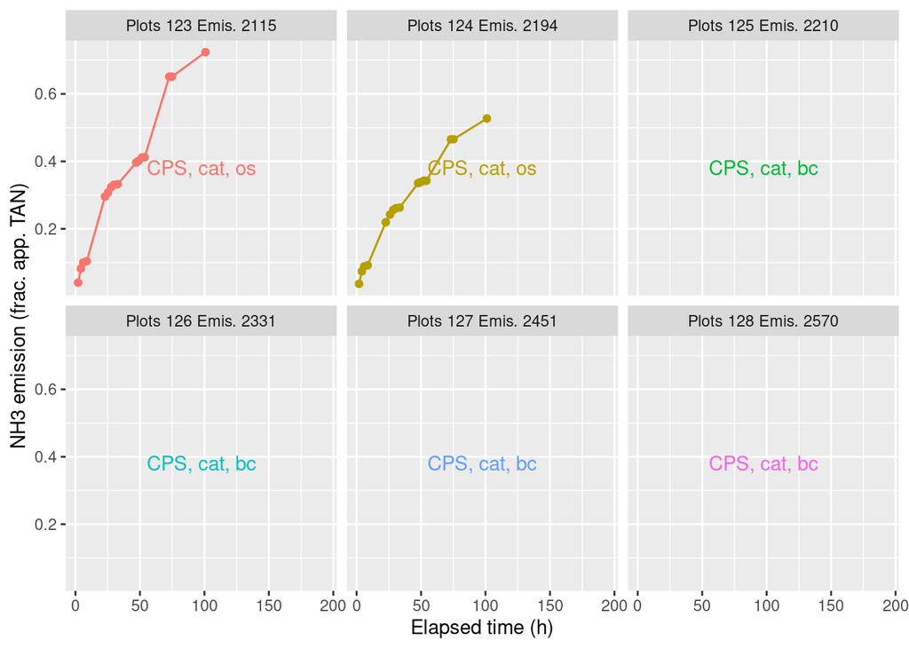

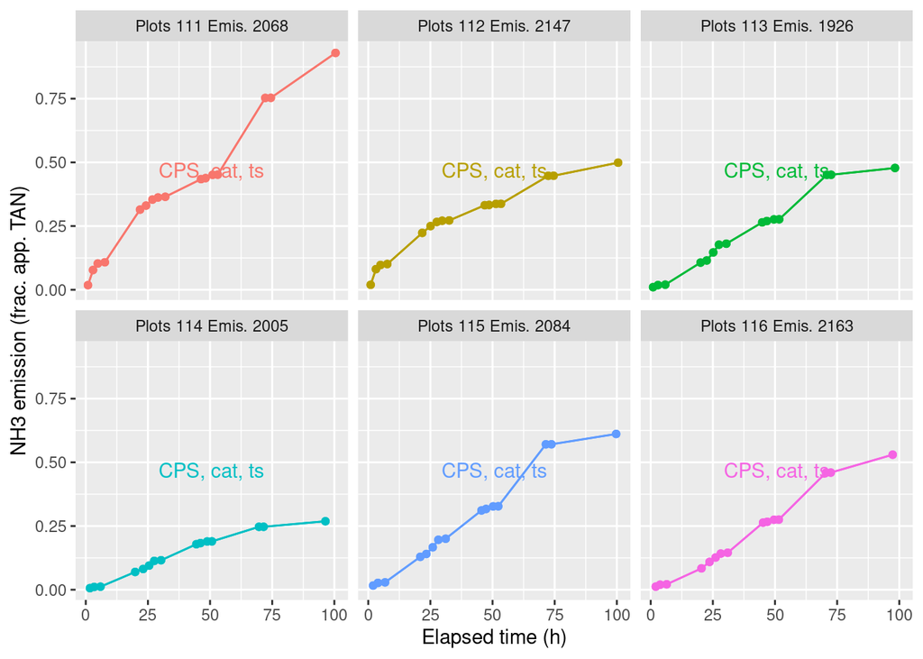

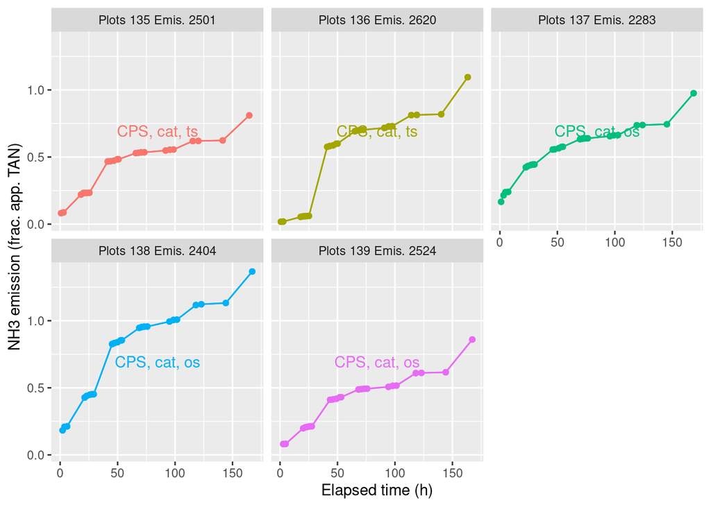

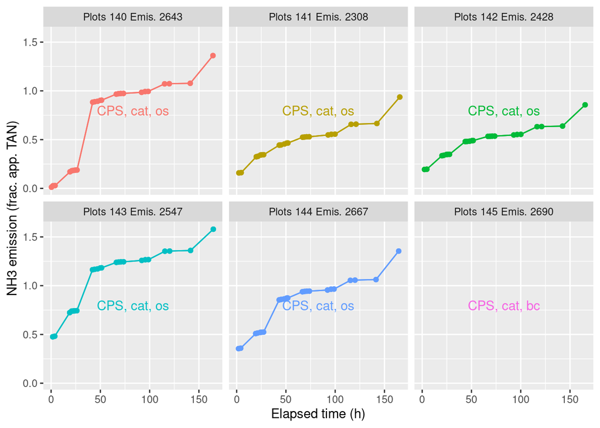

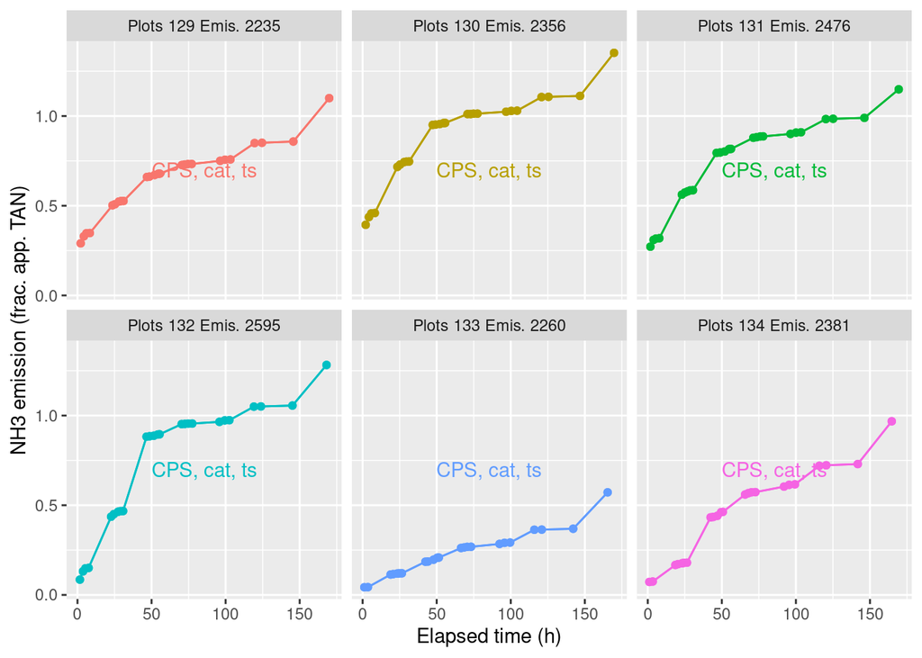

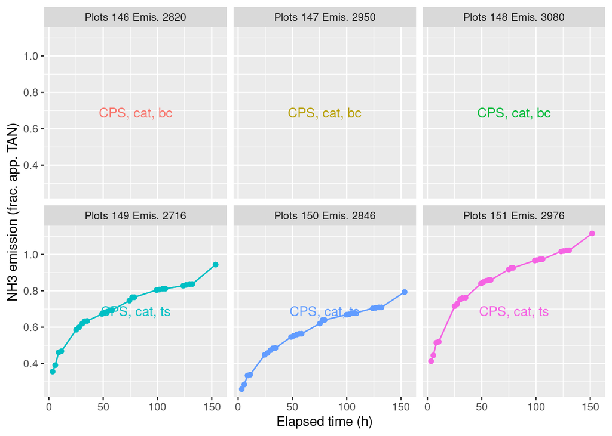

[26 more figures not shown]

## Final cumulative emission

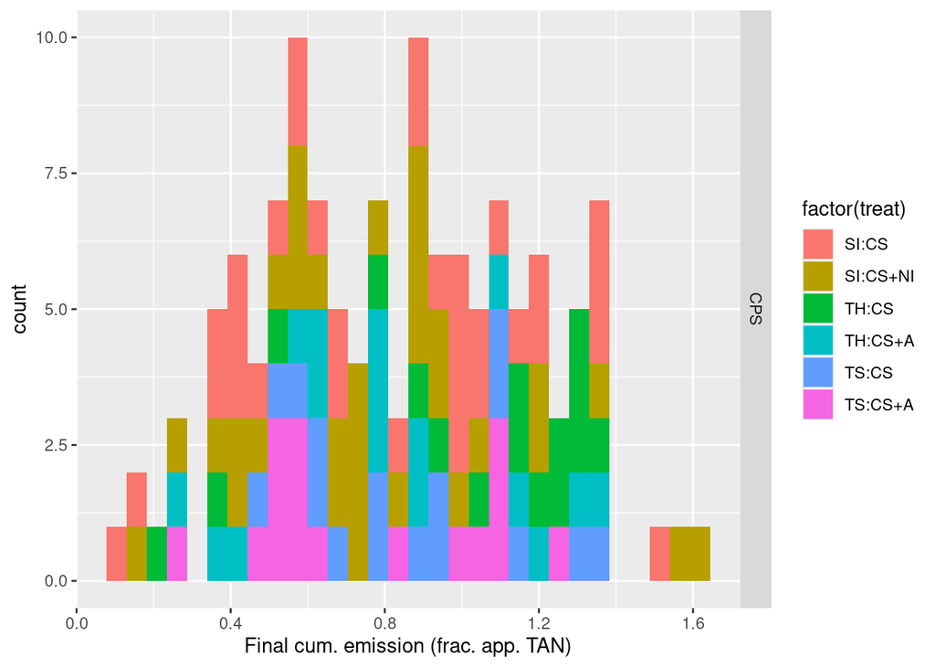

## Relative versus absolute emission

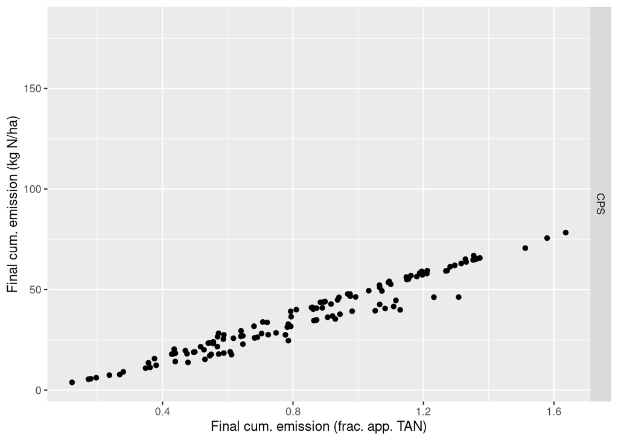

## Flux

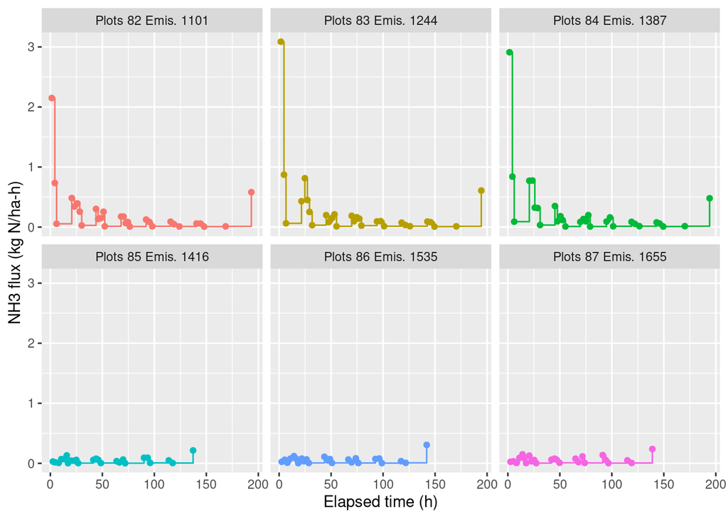

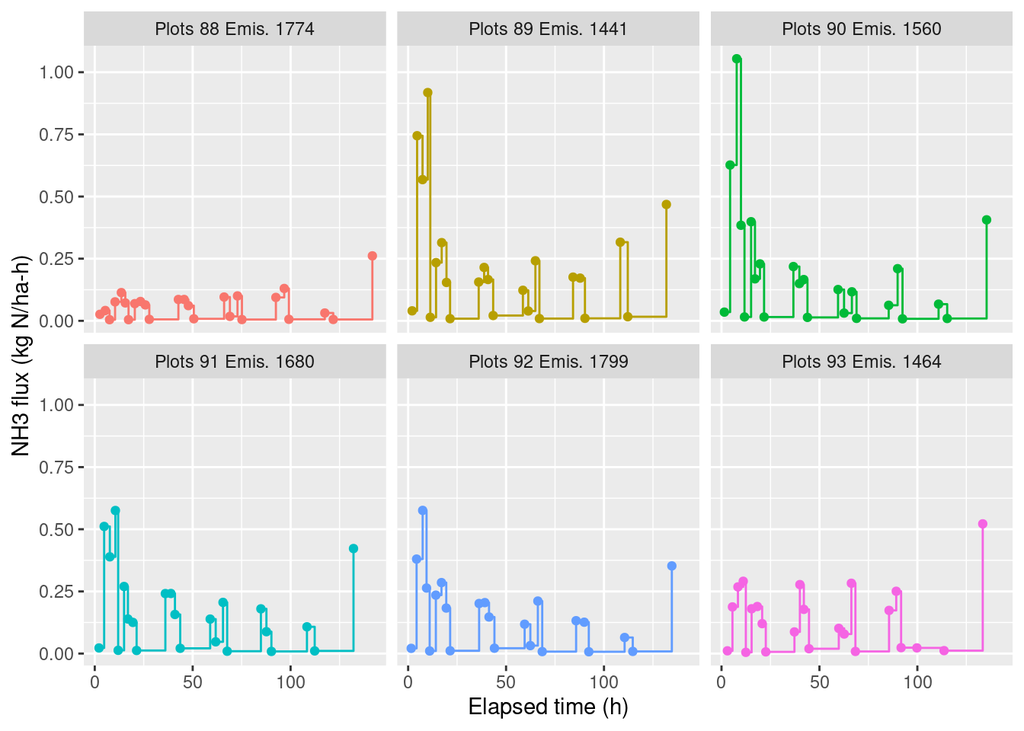

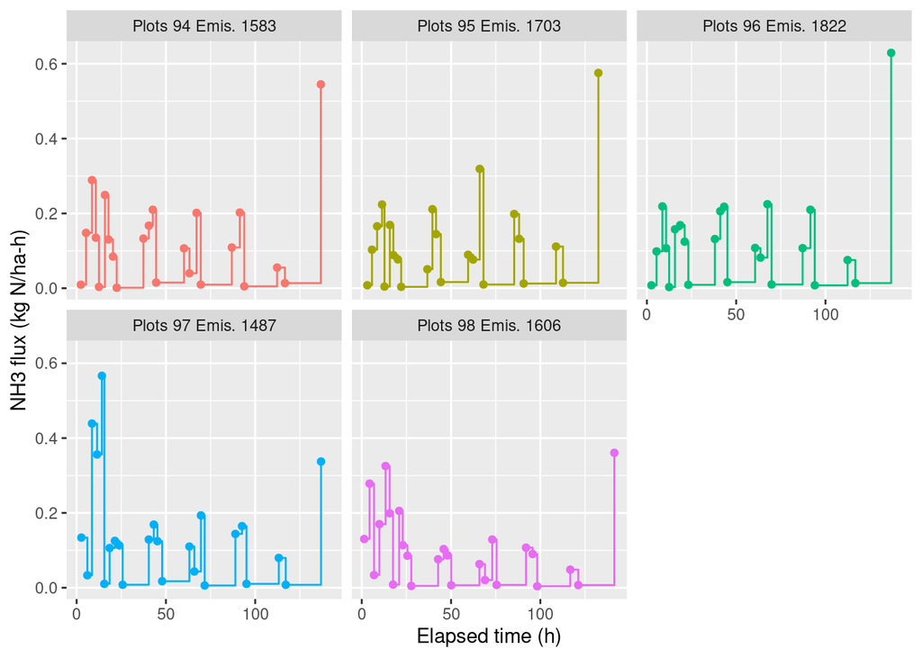

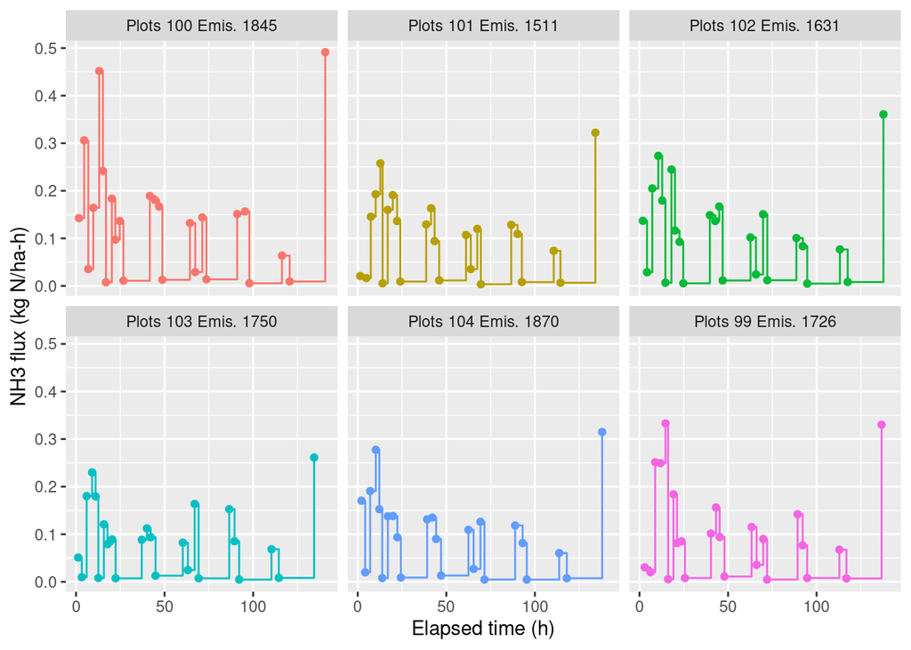

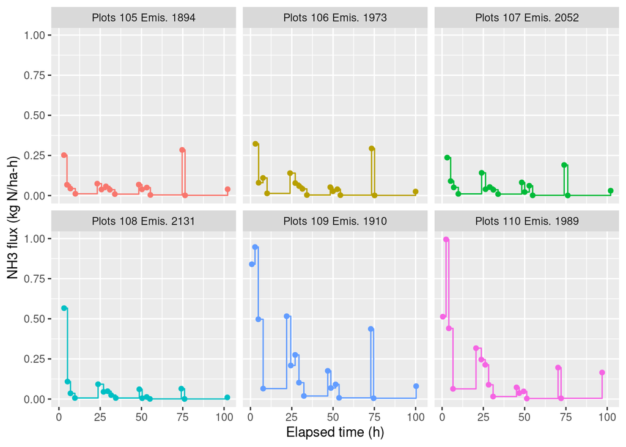

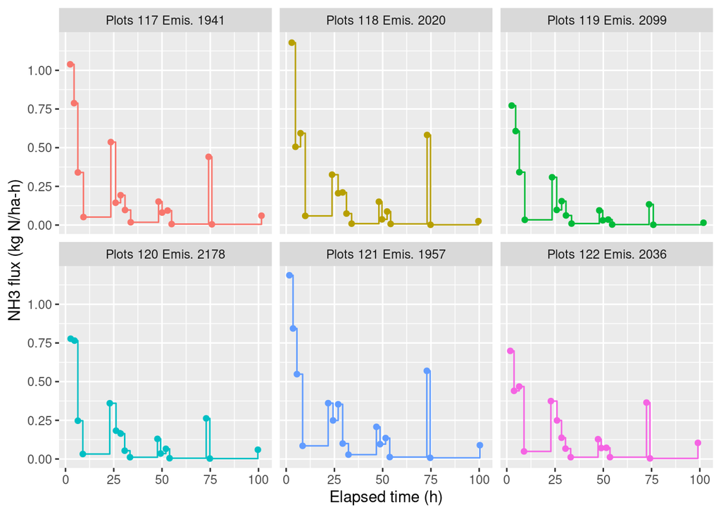

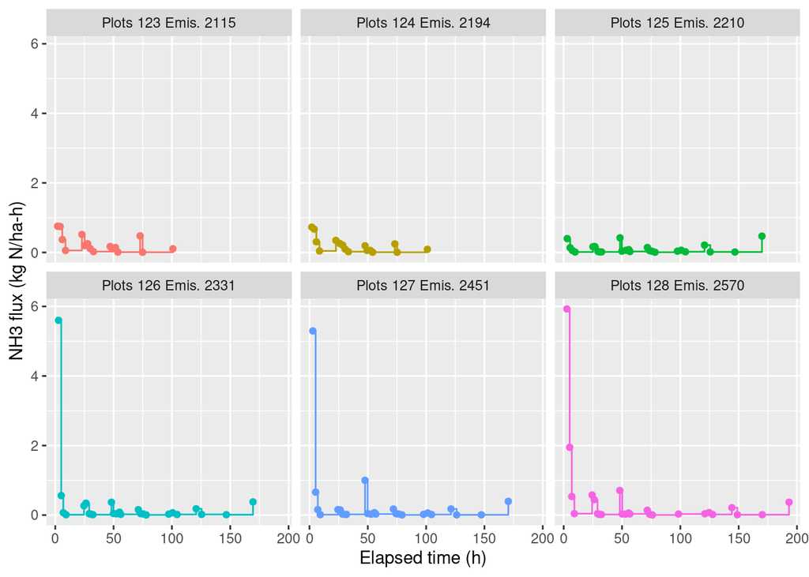

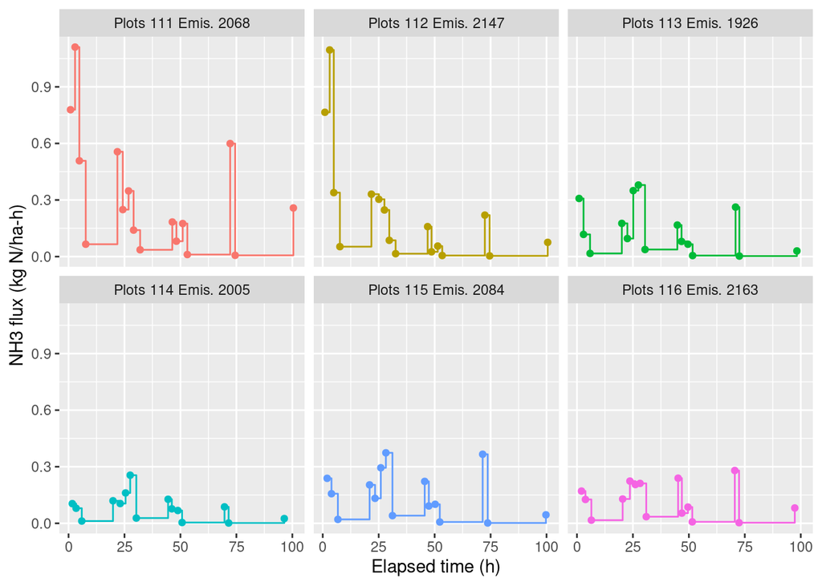

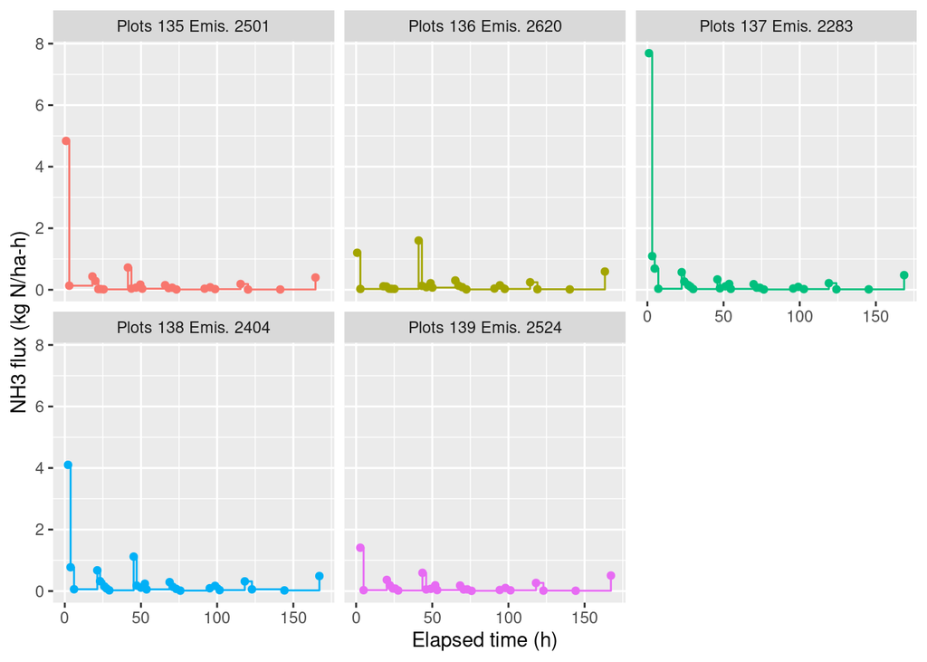

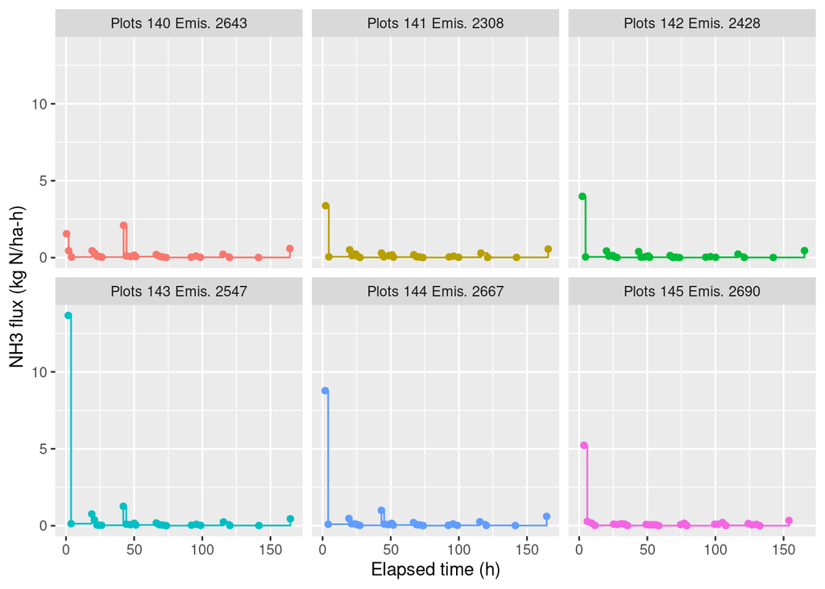

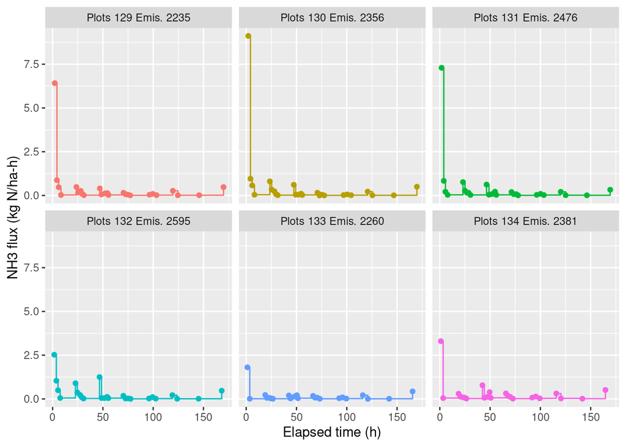

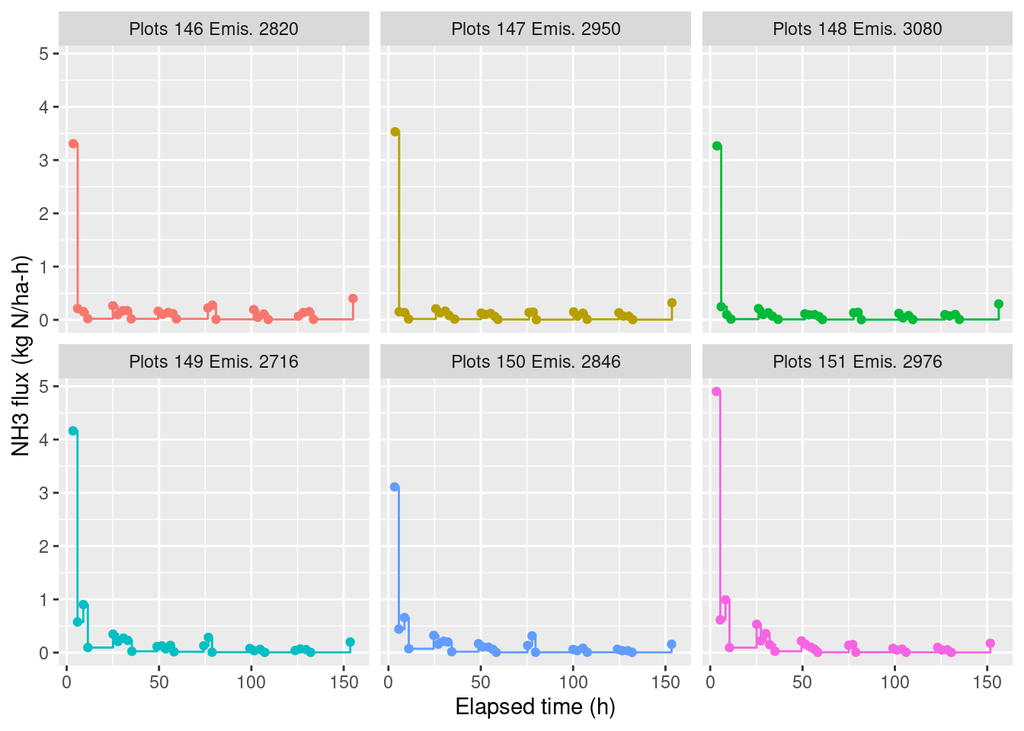

[64 more figures not shown]

## Weather data

[figure not shown]

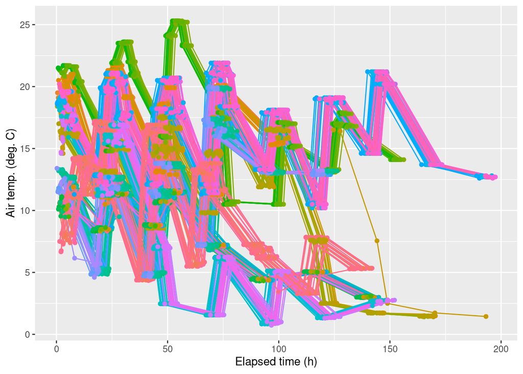

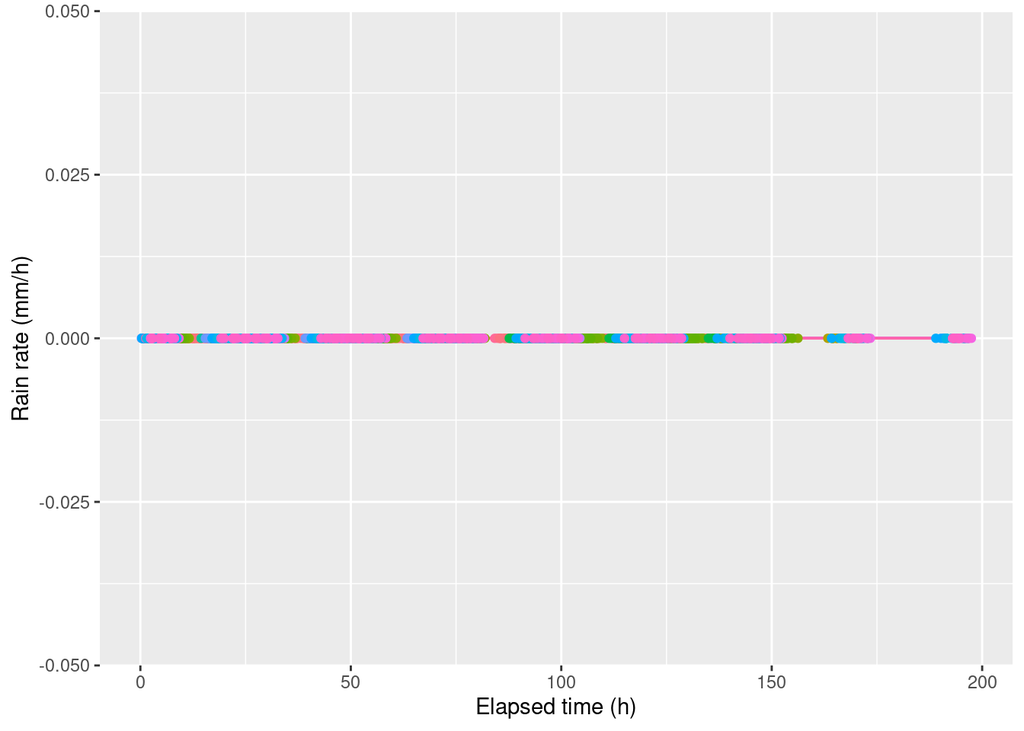

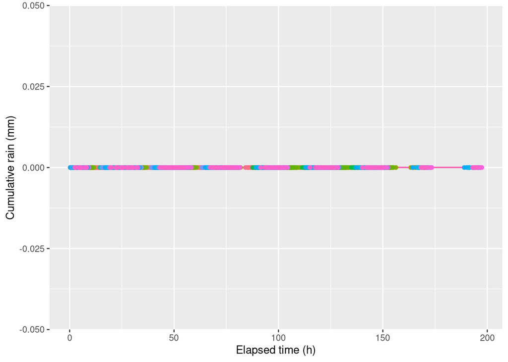

## Manure and application

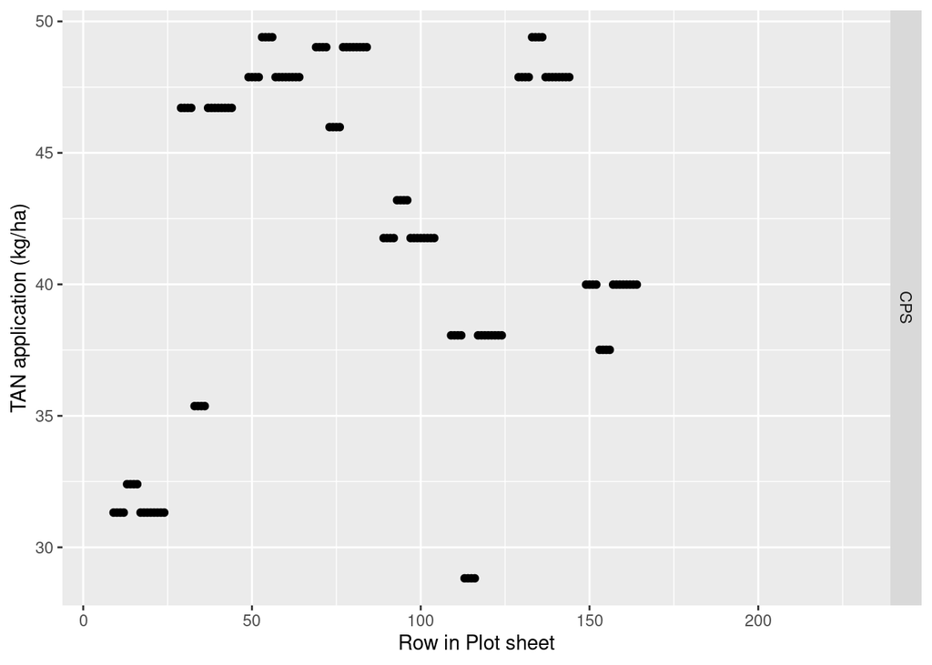

# 10. `dfsumm` summary

## Plot-level data

[output not shown]

[output cut: 362 more lines]

```
## Maximum                           Trailing shoe          ts        <NA>
## Mean                                       <NA>        <NA>        <NA>
## Unique (excld. NA)                            4           4           0
## Missing values                                0           0         224
## Sorted                                    FALSE       FALSE        <NA>
##
##                    date.start
## Class                    Date
## Minimum            2019-03-20
## Maximum            2020-05-20
## Mean                     <NA>
## Unique (excld. NA)          8
## Missing values              0
## Sorted                  FALSE
##
```

## Interval-level emission data

[output not shown]

[output cut: 290 more lines]

```
## Maximum            2019-03-20          4280      228  Plots 99 Emis. 1726
## Mean                     <NA>          2140      121 Plots 203 Emis. 4014
## Unique (excld. NA)          1           224      224                  224
## Missing values              0             0        0                    0
## Sorted                   TRUE         FALSE    FALSE                FALSE
##
##                    ggplotgroup
## Class                   factor
## Minimum            (4.78,10.9]
## Maximum              (222,228]
## Mean                 (116,122]
## Unique (excld. NA)          38
## Missing values               0
## Sorted                   FALSE
##
```